# (PSL) Regression Tree

```r
library(ggplot2)
library(rpart)
library(rpart.plot)
library(tree)
```

```r
url = "https://liangfgithub.github.io/Data/HousingData.csv"
Housing = read.csv(url)
```

There are two R packages for tree models, `tree` and `rpart`. We will mainly use `rpart`. The package `tree` is called for its command `partition.tree`, which we use to generate the first figure.

## The tree Package

The syntax for fitting a regression tree with `tree` is similar to that used for linear regression models. In this example, we use just two predictors, longitude and latitude, from the Housing data to predict the variable Y.

```r
trfit= tree(Y ~ lon + lat, data = Housing)
small.tree = prune.tree(trfit, best = 7)
small.tree
```

```
node), split, n, deviance, yval
      * denotes terminal node

  1) root 506 84.1800 3.035
    2) lon < -71.0667 202 16.8800 3.297 *
    3) lon > -71.0667 304 44.1400 2.860
      6) lon < -71.0155 185 32.8300 2.752
       12) lat < 42.241 147 27.4400 2.671
         24) lat < 42.1698 18  0.8337 3.104 *
         25) lat > 42.1698 129 22.7700 2.611
           50) lon < -71.0332 102 15.4200 2.707
            100) lat < 42.2011 51  3.5830 2.525 *
            101) lat > 42.2011 51  8.4700 2.888 *
           51) lon > -71.0332 27  2.8910 2.250 *
       13) lat > 42.241 38  0.6923 3.066 *
      7) lon > -71.0155 119  5.8160 3.028 *
```

```r
par(mfrow = c(1, 2))
plot(small.tree)
text(small.tree, cex = .75)
```

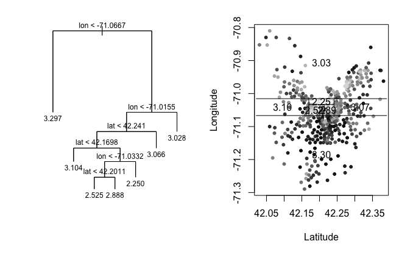

```r
price.quantiles = cut(Housing$Y, quantile(Housing$Y, 0: 20 / 20),
  include.lowest = TRUE)
plot(Housing$lat, Housing$lon, col = grey(20: 1 / 21)[price.quantiles],
  pch = 20, ylab = "Longitude", xlab = "Latitude")
partition.tree(small.tree, ordvars = c("lat", "lon"), add = TRUE)
```

Detach the `tree` package and switch to the `rpart` package.

```r
detach("package:tree")
```

## The rpart Package

### Fit a Tree

The syntax for fitting a regression tree with `rpart` closely resembles that used for linear regression models. In this example, we use the housing dataset to build a regression tree that predicts the target variable Y, using all other available columns as potential predictors. The default tree plot may not be visually appealing, so for better visualization, we can use the `rpart.plot` package.

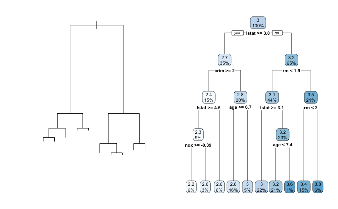

```r
set.seed(1234)
tr1 = rpart(Y~., data = Housing)
par(mfrow = c(1, 2))
plot(tr1)
rpart.plot(tr1)
```

- Understanding the Fitted Tree:

  Starting at the root node, the average value for all observations is 3, representing 100% of the data points. The first split occurs based on the variable `lsat`. The left node contains roughly 35% of the samples with an average of 2.7, while the right node contains the remaining 65% with an average of 3.2. Leaf nodes appear at the bottom, and their color shading indicates the magnitude of their predictions.

### Cross-validation

Cross-validation is automatically performed when using the `rpart` command. To inspect the cross-validation for pruning, use the `printcp` command, which provides a table.

- `CP` means **Complexity Parameter**, which is a scaled version of $\alpha$ (the price or penalty we pay for keeping a split)
- `nsplit` means the number of splits; the number of leaf nodes (or size of a tree) is equal to `nsplit` + 1
- `rel error` and `xerror` are the training error (RSS) and CV error, but these values are relative to a reference training error at the root node.

Connection between $\alpha$ and CP

$$RSS(T) + \alpha |T|, \quad \frac{RSS(T)}{RSS(\text{root})} + CP \cdot
|T|$$

```r
printcp(tr1)
```

```
Regression tree:
rpart(formula = Y ~ ., data = Housing)

Variables actually used in tree construction:
[1] age   crim  lstat nox   rm

Root node error: 84.178/506 = 0.16636

n= 506

         CP nsplit rel error  xerror     xstd
1  0.464749      0   1.00000 1.00266 0.074595
2  0.157620      1   0.53525 0.55009 0.037433
3  0.077637      2   0.37763 0.39504 0.034672
4  0.034542      3   0.29999 0.33653 0.031127
5  0.022416      4   0.26545 0.31014 0.031366
6  0.020665      5   0.24304 0.28779 0.027946
7  0.016709      6   0.22237 0.27085 0.026521
8  0.012136      7   0.20566 0.25969 0.025669
9  0.011932      8   0.19353 0.25558 0.025637
10 0.010000      9   0.18159 0.25558 0.025637
```

### Pruning

We can employ the `prune` command to obtain the optimal subtree by providing specific Complexity Parameter (CP) values.

```r
prune(tr1, cp = 0.3)
prune(tr1, cp = 0.2)
prune(tr1, cp = 0.156)
```

A CV path plot

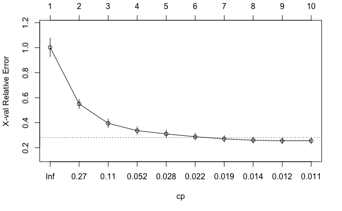

```r
plotcp(tr1)
```

If you’re uncertain whether the cross-validation error has reached its minimum, consider starting with a larger tree.

```r
tr2 = rpart(Y~., data = Housing,
  control = list(cp = 0, xval = 10))
printcp(tr2)
plot(tr2)
plotcp(tr2)
```

### Optimal CP Value

We can use either the minimum cross-validation error or the One Standard Error (1-SE) rule to choose the optimal CP value for pruning.

```r
# index of CP with lowest xerror
opt = which.min(tr2$cptable[, "xerror"])
# the optimal CP value
tr2$cptable[opt, 4]
```

```r
# upper bound for equivalent optimal xerror
tr2$cptable[opt, 4] + tr2$cptable[opt, 5]

# row IDs for CPs whose xerror are equivalent to min(xerror)
tmp.id = which(tr2$cptable[, 4] <= tr2$cptable[opt, 4] +
  tr2$cptable[opt, 5])
tmp.id = min(tmp.id)
# CP.1se = any value between row(tmp.id) and(tmp.id - 1)
CP.1se = (tr2$cptable[tmp.id -1, 1] + tr2$cptable[tmp.id, 1]) / 2

# Prune tree with CP.1se
tr3 = prune(tr2, cp = CP.1se)
```

### More on the CP Table

Understand the relationship between the 1st column and the 3rd column of the CP table.

The difference between adjacent `rel error` in the table is equivalent to the corresponding CP values. This difference signifies the improvement gained in RSS by adding an additional split, effectively setting the “cost” of that split.

```r
cbind(tr2$cptable[, 1], c(-diff(tr2$cptable[, 3]), 0))
```

### Making Predictions

After the tree is fit, the `predict` function from the `rpart` package can be used for making predictions on new or existing data.

```r
?predict.rpart
```